# Multivariate CAViaR

# Methods Used

The appeal of this model is that it combines the crisp statistical assumptions with the flexibility required to model financial returns. However, the model still runs into issues when a training sample is totally unrepresentative of the testing period - a common problem in statistical analysis. Initial motivations for this paper involved analyzing two stocks - Amazon (ticker: AMZN) and Proctor & Gamble (ticker: PG) and their performance during the Great Recession (specifically, the last 200 trading days of 2008). A relevant question of a financial institution would understandably be how their risk model performed during 2008, a highly volatile period which was driven by the “most severe financial crisis since the Great Depression”, according to Gary Becker (Becker 2008), a Nobel-prize winning economist. Interestingly, the univariate CAViaR forecast for Amazon was fairly accurate whereas the forecast for PG was not. One reason for this could be the fact that a stock like Amazon was highly volatile during the training sample, which included return data starting from the second quarter of 2004, but PG was fairly stable. How would it be possible for a univariate model such as CAViaR, that does not explicitly account for other factors, to forecast well? What if a volatile stock such as AMZN were included into the forecast for PG - would it improve the prediction?

[output not shown]

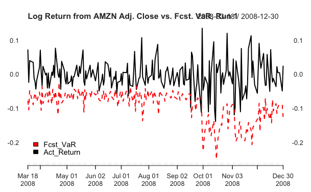

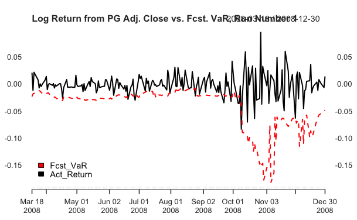

Accuracy of VaR Forecast for AMZN and PG Over Last 200 Trading Days in 2008

|  | AMZN | PG |
| --- | --- | --- |
| VaR Break Rate | 0.025 | 0.055 |
| Theoretical VaR | 0.010 | 0.010 |

Note:  
Tested Using the Symmetric Absolute Value Model

Thus, the idea of combining stocks into a multivariate setting to capture correlations and better forecast risk was formed. A natural choice appeared to be the diffusion index model, originally developed by Stock and Watson for predicting conditional means (Stock and Watson 2002b, 2002a). The model for forecasting the conditional mean is specified below.

## Diffusion Index Model

A useful means of predicting stock movements in the future is the Stock and Watson diffusion index. The model is outlined below, which is adapted from $\textit{Multivariate Time Series Analysis With R and Financial Applications}$ by Ruey S. Tsay (Tsay 2014).

There are two relevant equations, $\boldsymbol{z_t} = \boldsymbol{Lf_t} + \boldsymbol{\epsilon_t}$ and $y_{t+h} = \boldsymbol{\beta^\prime f_t} + \boldsymbol{e_{t+h}}$.

In the first equation, $\boldsymbol{z_t} = (z_{1t}, ...., z_{kt})^\prime$ is an observed time series with mean 0, $\boldsymbol{f_t}$ is an m-dimensional vector of common factors with mean 0 and identity covariance matrix, $\boldsymbol{L}$ is a $k \times m$ loading matrix, and $\boldsymbol{\epsilon_t}$ is an independent and identically distributed (i.i.d.) sequence of random vectors with mean 0 and covariance matrix $\boldsymbol{\Sigma_e}$.

In the second equation, which represents the h-step ahead prediction based on $\boldsymbol{f_t}$, $y_t$ is the scalar time series of interest, $h$ is the forecast horizon, $\boldsymbol{\beta}$ represents the vector of coefficients, and $\boldsymbol{e_t}$ is a sequence of uncorrelated random variables with mean 0 and constant variance.

To model the data, principal component analysis is performed on the covariates described below to obtain an estimate of $\boldsymbol{f_t}$. When modeling the conditional mean, the $\boldsymbol{\beta}$ coefficients are estimated using ordinary least squares, however in the specification below they are not. A specific formulation mentioned in the textbook is as follows, where the individuals diffusion indices are given by $f_it$, and the goal is a one-step ahead prediction of $y_t$:

$$y_{t+1} = \beta_0 + \sum_{i=1}^m \beta_i f_{it} + e_t.$$

## Univariate CAViaR Model Specifications

However, work needed to be done to align the diffusion index model with the CAViaR model, which is defined below. The following variables are required for use in the CAViaR model. For ease of notation, these are sourced directly from the Engle and Manganelli 2004 CAViaR paper (Engle and Manganelli 2004), with some added description:

- $(y_t)_{t=1}^T$ is a “vector of portfolio returns”
- $\theta$ is the “probability associated with VaR” (a 5% VaR would mean $\theta = 0.05$)
- $\boldsymbol{x_t}$ is a “vector of time $t$ observable variables”
- $f_t(\boldsymbol{\beta}) \equiv f_t(\boldsymbol{x_{t-1}, \boldsymbol{\beta_\theta}})$ is the “time $t$”, “$\theta$ quantile of the distribution of portfolio returns formed at time $t-1$”

The authors then describe a “generic CAViaR specification” as follows:

$$f_t(\boldsymbol{\beta}) = \beta_0 + \sum_{i=1}^q \beta_i f_{t-1}(\boldsymbol{\beta}) + \sum_{j=1}^r \beta_{q+j} l(\boldsymbol{x_{t-j}})$$

What is interesting about the general setup is that there are two main components to the model - lagged observed variables (represented by $l$) and lagged values of unknown parameters, which in the specification below is used as moving average terms. As such, it is reasonable to generalize the specifications below as nonlinear ARMA models where $y_{t-1}$ terms refer to previous returns, whereas $f_{t-1}(\beta_1)$ terms refer to previous predictions.

### Adaptive CAViaR Model

Consider the following model:

$$f_t(\beta_1) = f_{t-1}(\beta_1) + \beta_1\left[\left(1+ \exp(G[y_{t-1} - f_{t-1}(\beta_1)]) \right)^{-1} - \theta \right]$$

Following Engle and Manganelli’s 2004 paper, we choose $G = 10$, so that is what is used in the results section of this paper. The authors state the reason for the seemingly arbitrary choice is that while “the parameter G itself could be estimated; however, this would go against the spirit of this model, which is simplicity”. Previous sensitivity analysis showed that running the adaptive model with $G = 5$ did not materially affect the VaR predictions - the accuracy was not changed. While this model is nonlinear in G and total scale invariance in $G$ would be surprising given the nonlinear relationship, the fact that the other fitted parameters likely adjusted is not surprising.

### Symmetric Absolute Value CAViaR Model

Below is the symmetric absolute value CAViaR model:

$$f_t(\boldsymbol{\beta}) = \beta_1 + \beta_2f_{t-1}(\boldsymbol{\beta}) + \beta_3|y_{t-1}|.$$

### Asymmetric Slope CAViaR Model

Below is the asymmetric slope CAViaR model:

$$f_t(\boldsymbol{\beta}) = \beta_1 + \beta_2f_{t-1}(\boldsymbol{\beta}) + \beta_3(y_{t-1})^+ + \beta_4(y_{t-1})^-.$$

### Indirect GARCH (1,1) CAViaR Model

Below is the Indirect GARCH (1,1) model:

$$f_t(\boldsymbol{\beta}) = (\beta_1 + \beta_2f_{t-1}^2(\boldsymbol{\beta}) + \beta_3y_{t-1}^2)^{1/2}.$$

## Multivariate CAViaR Model Specifications

The multivariate CAViaR model takes inspiration from the models described above in several specifications, as mentioned in the original specifications. The general model form looks like the specification below:

$$f_t(\boldsymbol{\beta}) = \beta_0 +\sum_{i=1}^p \beta_i y_{t-i} + \sum_{j=1}^m \beta_{j+p} f_{j,t-1} + e_t.$$

As with the univariate CAViaR model, the object of interest is a $\theta$ percentile return and the model is fit iteratively to minimize the loss function on the training data. However, there are some notable differences between the univariate model and the multivariate model. First, there are no moving average terms (lagged error terms) - the reasoning for this is because this model aims for a clear economic interpretation, and crisp interpretations of MA models are harder to create. Also, moving average models require recursive estimation since error terms are not observed, and so developing a method to work with these errors in a robust regression framework is challenging.

Second, in some of the specifications below, there are lagged return variables. This is similar to the univariate CAViaR specification, though there is often more than 1 lag as in the univariate model - there are $p$ lags in the dataset. Third, in all of the specifications below, there are $m$ diffusion indices used in each model lagged by one time step to avoid look-ahead bias.

### Multivariate CAViaR: No Lags Model

$$f_t(\boldsymbol{\beta}) = \beta_0 +\sum_{j=1}^m \beta_{j} f_{j,t-1} + e_t$$

### Multivariate CAViaR with Autoregressive Terms Added

$$f_t(\boldsymbol{\beta}) = \beta_0 +\sum_{i=1}^p \beta_i y_{t-i} + \sum_{j=1}^m \beta_{j+p} f_{j,t-1} + e_t$$

### Multivariate CAViaR with Symmetric Absolute Value Autoregressive Terms Added

$$f_t(\boldsymbol{\beta}) = \beta_0 +\sum_{i=1}^p \beta_i |y_{t-i}| + \sum_{j=1}^m \beta_{j+p} f_{j,t-1} + e_t$$

### Multivariate CAViaR with Asymmetric Slope Autoregressive Terms Added

$$f_t(\boldsymbol{\beta}) = \beta_0 +\sum_{i=1}^p \beta_i (y_{t-i})_+ + \sum_{j=p+1}^{2p} \beta_i (y_{t-i})_- + \sum_{k=1}^m \beta_{k+2p} f_{k,t-1} + e_t$$

## Fitting the Models

To fit the models, an optimal value of $m$ diffusion indices and $p$ autoregressive terms are added (or $2p$ in the case of the asymmetric slope model). The optimal values of these parameters are determined using a validation dataset. In all of the runs below, there are a total of 5 years of trading days, or about 1,260 days assuming 252 trading days a year. The adjusted closing prices are logged and differenced, shortening the dataset by one. After doing this, the last 250 data points are reserved as test data, and the 250 data points before that are used as a validation set. Measured by the loss function written out below, the values of $p$ and $m$ that minimize losses are chosen and the optimal model is refit over both the training and the validation data combined and then evaluated on the test data. Note that there is an optimal model which is chosen for each of the four multivariate CAViaR specifications described above, so there are 4 optimal sets of $p$ and $m$ chosen for each set of models. Thus, there are 8 models compared on the test data - 4 univariate CAViaR models and 4 multivariate CAViaR models.

From the CAViaR paper, the $\theta$th regression quantile is defined as any $\boldsymbol{\hat{\beta}}$ that solves the following loss function:

$$\overset{argmin}\beta \frac{1}{T}\sum_{t=1}^T [\theta - I(y_t < f_t(\boldsymbol{\beta}))][y_t - f_t(\boldsymbol{\beta})]$$

# Theoretical Guarantees of Consistency and Asymptotic Normality

Part of the reason for working with the CAViaR and diffusion index is their strong theoretical guarantees about consistency and asymptotic normality. Indeed, following the results in Engle and Manganelli (Engle and Manganelli 2004), there are 8 conditions required for consistency of the $\beta$ estimate and 4 required for asymptotic normality. The paper states that the model specified by:

$$y_t = f(y_{t-1}, \boldsymbol{x}_{t-1},..., y_1, \boldsymbol{x}_1; \boldsymbol{\beta}^0) + \epsilon_{t \theta} [Quant_\theta (\epsilon_{t \theta} | \Omega_t) = 0]$$
$$\equiv f_t(\boldsymbol{\beta^0}) + \epsilon_{t \theta}, t = 1,...,T$$

“where $f_1(\boldsymbol{\beta^0})$ is some given initial condition, $\boldsymbol{x_t}$ is a vector of exogenous of predetermined variables, $\boldsymbol{\beta^0} \in \mathbb{R}^p$ is the vector of true unknown parameters that need to be estimated, and $\Omega_t = [y_{t-1}, \boldsymbol{x}_{t-1},...,y_1, \boldsymbol{x}_1; f_1 (\boldsymbol{\beta}^0)]$ is the information set available at time $t$”, and $\boldsymbol{\hat{\beta}}$ is the parameter vector that minimizes the loss function specified above. According to theorems in the paper, they state that under favorable conditions, $\boldsymbol{\hat{\beta}}$ is consistent and asymptotically normal.

## Consistency

Per Engle and Manganelli, under the model specified above and using 8 assumptions given below, $\boldsymbol{\hat{\beta}} \overset{p}\rightarrow \boldsymbol{\beta^0}$ where $\boldsymbol{\hat{\beta}}$ is the parameter vector that minimizes the loss function specified above. There are 8 assumptions listed in the paper.

1. “$(\Omega, F, P)$ is a complete probability space, and {$\epsilon_{t \theta}$, $\boldsymbol{x}_t$}, t = 1,2,…. are random vectors on this space”
2. “The function $f_t(\boldsymbol{\beta}): \mathbb{R}^{k_t} \times B \rightarrow \mathbb{R}$ is such that for each $\boldsymbol{\beta} \in B$, a compact subset of $\mathbb{R}^p, f_t(\boldsymbol{\beta})$ is measurable with respect to the information set $\Omega_t$ and $f_t(\cdot)$ is continuous in $B$, $t = 1,2,....,$ for a given choice of explanatory variables {$y_{t-1}, \boldsymbol{x}_{t-1}, ..., y_{1}, \boldsymbol{x}_{1}$}.”
3. “Conditional on all of the past information $\Omega_t$, the error terms $\epsilon_{t \theta}$ form a stationary process, with continuous conditional density $h_t(\epsilon | \Omega_t)$.”
4. “There exists $h > 0$ such that for all $t, h_t(0 | \Omega_t) \geq h$.”
5. “|$f_t(\boldsymbol{\beta})$| < $K(\Omega_t)$ for each $\boldsymbol{\beta} \in B$ and for all $t$, where $K(\Omega_t)$ is some (possibly) stochastic function of variables that belong to the information set, such that $\mathbb{E}(|K(\Omega_t)|) \leq K_0 < \infty$, for some constant $K_0$”
6. “$\mathbb{E}[|\epsilon_{t\theta}|] < \infty$ for all $t$”
7. “{$[\theta - I(y_t < f_t(\boldsymbol{\beta}))][(y_t - f_t(\boldsymbol{\beta}))]$} obeys the uniform law of large numbers”
8. “For every $\xi > 0$, there exits a $\tau > 0$ such that if ||$\boldsymbol{\beta} = \boldsymbol{\beta}^0$|| $\geq \xi$, then $\lim \inf_{T \rightarrow \infty} T^{-1} \Sigma P[|f_t(\boldsymbol{\beta}) - f_t(\boldsymbol{\beta^0})| > \tau] >0$”

When analyzing real data, it’s hard to verify any assumptions exactly, but one that is most controversial might be the third assumption - indeed, it seems highly unlikely that given all the past information, there would be a stationary process.

## Asymptotic Normality

Also per Engle and Manganelli, under the same assumptions required for consistency as well as the assumptions below, there is a guarantee of asymptotic normality:

$$\sqrt{T} \boldsymbol{A}_T^{-1/2}\boldsymbol{D}_T (\boldsymbol{\hat{\beta}} - \boldsymbol{\beta}^0) \overset{d}\rightarrow \mathcal{N}(0, \boldsymbol{I})$$

where

$$\boldsymbol{A}_T \equiv \mathbb{E} \left[T^{-1} \theta (1-\theta) \sum_{t=1}^T \nabla' f_t(\boldsymbol{\beta}^0) \nabla f_t(\boldsymbol{\beta}^0) \right]$$

and

$$\boldsymbol{D}_T \equiv \mathbb{E} \left[T^{-1} \sum_{t=1}^T h_t(0|\Omega_t)\nabla' f_t(\boldsymbol{\beta}^0) \nabla f_t(\boldsymbol{\beta}^0) \right]$$

There are 4 assumptions listed in the paper required for asymptotic normality to hold. As with the assumptions required for consistency, these seem fairly standard as well:

1. “$f_t (\boldsymbol{\beta})$ is differentiable in $B$ and for all $\boldsymbol{\beta}$ and $\boldsymbol{\gamma}$ in a neighborhood $\nu_0$ of $\boldsymbol{\beta^0}$, such that $||\boldsymbol{\beta} - \boldsymbol{\gamma}|| \leq d$ for $d$ sufficiently small and for all $t$:”
1. “$||\nabla f_t (\boldsymbol{\beta})|| \leq F(\Omega_t)$, where $F(\Omega_t)$ is some (possibly) stochastic function of variables that belong to the information set and $\mathbb{E}(F(\Omega_t)^3) \leq F_0 < \infty$, for some constant $F_0$.”
2. “$||\nabla f_t (\boldsymbol{\beta})- \nabla f_t (\boldsymbol{\gamma})|| \leq M(\Omega_t, \boldsymbol{\beta}, \boldsymbol{\gamma}) = \mathcal{O}(||\boldsymbol{\beta} - \boldsymbol{\gamma}||)$, where $M(\Omega_t, \boldsymbol{\beta}, \boldsymbol{\gamma})$ is some function such that $\mathbb{E}[M(\Omega_t, \boldsymbol{\beta}, \boldsymbol{\gamma})]^2 \leq M_0||\boldsymbol{\beta} - \boldsymbol{\gamma}|| < \infty$ and $\mathbb{E}[M(\Omega_t, \boldsymbol{\beta}, \boldsymbol{\gamma})]F(\Omega_t)] \leq M_1|\boldsymbol{\beta} - \boldsymbol{\gamma}|| < \infty$ for some constants $M_0$ and $M_1$.”

2a. “$h(\epsilon|\Omega_t) \leq N < \infty \text{ } \forall t$, for some constant $N$.”

2. “$h(\epsilon|\Omega_t)$ satisfies the Lipschitz condition $|h_t(\lambda_1 | \Omega_t) - h_t(\lambda_2 | \Omega_t)| \leq L|\lambda_1 - \lambda_2|$ for some constant $L < \infty \text{ } \forall t$.”
3. “The matrices $\boldsymbol{A}_T \equiv \mathbb{E} \left[T^{-1} \theta (1-\theta) \sum_{t=1}^T \nabla' f_t(\boldsymbol{\beta}^0) \nabla \times f_t(\boldsymbol{\beta}^0) \right]$ and $\boldsymbol{D}_T \equiv \mathbb{E} \left[T^{-1} \sum_{t=1}^T h_t(0|\Omega_t)\nabla' f_t(\boldsymbol{\beta}^0) \times \nabla f_t(\boldsymbol{\beta}^0) \right]$ have the smallest eigenvalues bounded below by a positive constant $T$ for sufficiently large.”
4. “The sequence {$T^{-1/2} \sum_{t=1}^T[\theta - I(y_t < f_t(\boldsymbol{\beta}^0))] \nabla'f_t(\boldsymbol{\beta}^0)$} obeys the central limit theorem.”

As with the consistency conditions, these seem reasonable enough - the data considered in this analysis seems well-behaved enough such that these conditions are satisfied.

# Data Used

The response variable used in this analysis is SPY, which is an exchange-traded fund that aims to track the performance of the S&P 500, which is discussed above. It is broadly used as a bellwether of the U.S. economy, and has the advantage of avoiding survivorship bias - while an individual stock might go bankrupt or merge with another, it is reasonable to assume that these issues do not apply with an ETF.

Following this logic, there are several classes of response variables used in this analysis. The first group is a set of U.S. sector ETFs obtained from Seeking Alpha (NA 2020). As with the response variable, these ETFs were publicly traded throughout the Great Recession of 2008.

1. Utilities (XLU)
2. Consumer Staples (XLP)
3. Healthcare (XLV)
4. Technology (XLK)
5. Consumer Discretionary (XLY)
6. Industrial (XLI)
7. Financial Services (XLF)
8. Basic Materials (XLB)
9. Energy (XLE)

The second group is Global Sector ETFs, also from Seeking Alpha (NA 2020). The rationale for including these is that perhaps some global exposure is useful in understanding the broader market.

1. Utilities (JXI)
2. Consumer Staples (KXI)
3. Healthcare (IXJ)
4. Telecommunications (IXP)
5. Technology (IXN)
6. Consumer Discretionary (RXI)
7. Industrial (EXI)
8. Financial Services (IXG)
9. Basic Materials (MXI)
10. Energy (IXC)

The third group is bond ETFs. Like the previous two groups, these ETFs potentially contain forward-looking information about the stock market. These ETFs were chosen because they were the first fixed-income ETFs available in the United States, and had enough history for this paper (NA 2017).

1. iShares 1-3 Year Treasury Bond Fund (SHY)
2. iShares 7-10 Year Treasury Bond Fund (IEF)
3. iShares 20+ Year Treasury Bond Fund (TLT)
4. iShares iBoxx $ Investment Grade Corporate Bond ETF (LQD)

Lastly, all of the above three groups are run together. One reason for having bond and stocks grouped together is the fact that bonds are somewhat of a substitute for equities, which tend to drop more in a period of crisis (Amadeo 2020). As such, some unexplained movements in the stock price could be picked up by bond movements.

In each run, the explanatory variables are lagged to avoid look-ahead bias. All of the runs analyze the difference of the log of the adjusted closing price. The reason for using the differenced log is that it closely approximates the percentage change of the price for small changes. The reason for using the adjusted closing prices is that an adjusted closing price excludes the effects of “corporate actions such as stock splits, dividends / distributions and rights offerings” (Gant 2019). While dividends are essential to study the long-term performance of a strategy, studying short-term price movements do not require understanding the effects of dividend reinvestment. While there are many candidate ETFs chosen, these were chosen because they all had price history going back through the beginning of 2004.

# Results

For the sake of brevity, the results with only U.S. ETFs, global ETFs, or bonds are not included in this paper. The results are similar to the results below. To test how well the models do at different VaR levels, 1%, 5%, and 10% are tested.

## Notation

Below is the notation used later in this paper. Items 2 - 5 listed below are new multivariate CAViaR models developed in this thesis; models 6 - 9 are from the established univariate CAViaR model developed by Engle and Manganelli.

1. SPY: SPY ETF
2. No AR: Multivariate CAViaR Model with no lags
3. AR: Multivariate CAViaR Model with $p$ lags
4. SAV AR: Multivariate CAViaR Model with $p$ absolute value lags
5. AS AR: Multivariate CAViaR Model with $2p$ lags with asymmetric slopes
6. SAV: Univariate CAViaR Model with symmetric absolute framework
7. Asym. Slope: Univariate CAViaR Model with asymmetric slope framework
8. Ind. GARCH: Univariate CAViaR Model with indirect GARCH framework
9. Adaptive: Univariate CAViaR Model with adaptive slope framework

## 2008 Test Period - All ETFs

### 1% VaR Graph

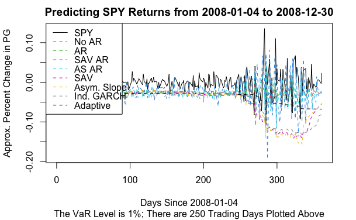

### 1% VaR Table - Multivariate Model

|  | No AR | AR | SAV AR | AS AR |
| --- | --- | --- | --- | --- |
| Losses | 0.736 | 0.737 | 1.733 | 0.863 |
| VaR Break Rate | 0.104 | 0.108 | 0.216 | 0.104 |

### 1% VaR Table - Univariate Model

|  | SAV | Asym. Slope | Ind. GARCH | Adaptive |
| --- | --- | --- | --- | --- |
| Losses | 0.208 | 0.213 | 0.219 | 0.355 |
| VaR Break Rate | 0.028 | 0.028 | 0.028 | 0.060 |

### 1% VaR - Optimal Parameters for Multivariate Model

|  | Optimal M | Optimal P |
| --- | --- | --- |
| No AR | 1 | NA |
| AR | 1 | 2 |
| SAV AR | 2 | 6 |
| AS AR | 1 | 2 |

### 5% VaR Graph

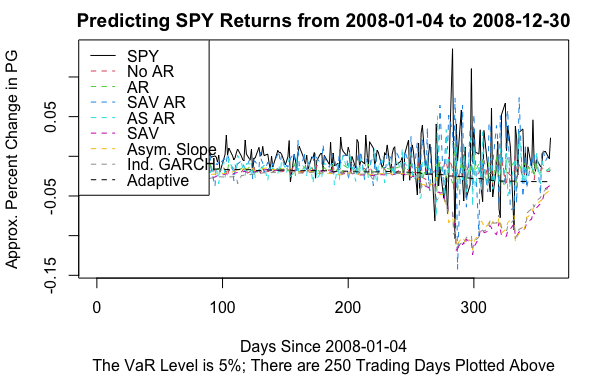

### 5% VaR Table - Multivariate Model

|  | No AR | AR | SAV AR | AS AR |
| --- | --- | --- | --- | --- |
| Losses | 1.148 | 1.236 | 2.391 | 1.371 |
| VaR Break Rate | 0.168 | 0.208 | 0.400 | 0.220 |

### 5% VaR Table - Univariate Model

|  | SAV | Asym. Slope | Ind. GARCH | Adaptive |
| --- | --- | --- | --- | --- |
| Losses | 0.651 | 0.654 | 0.640 | 0.956 |
| VaR Break Rate | 0.076 | 0.076 | 0.064 | 0.160 |

### 5% VaR - Optimal Parameters for Multivariate Model

|  | Optimal M | Optimal P |
| --- | --- | --- |
| No AR | 1 | NA |
| AR | 1 | 2 |
| SAV AR | 1 | 4 |
| AS AR | 9 | 1 |

### 10% VaR Graph

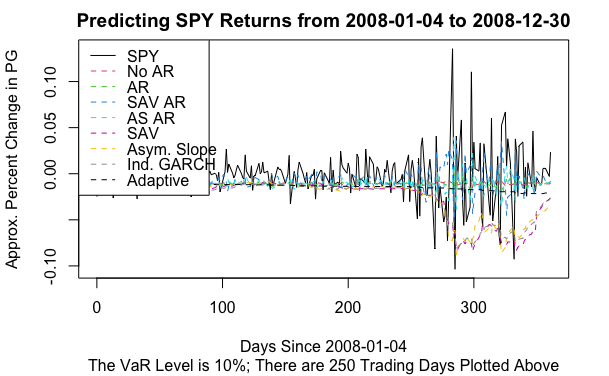

### 10% VaR Table - Multivariate Model

|  | No AR | AR | SAV AR | AS AR |
| --- | --- | --- | --- | --- |
| Losses | 1.521 | 1.549 | 1.797 | 1.644 |
| VaR Break Rate | 0.284 | 0.288 | 0.344 | 0.292 |

### 10% VaR Table - Univariate Model

|  | SAV | Asym. Slope | Ind. GARCH | Adaptive |
| --- | --- | --- | --- | --- |
| Losses | 1.077 | 1.066 | 1.068 | 1.366 |
| VaR Break Rate | 0.144 | 0.156 | 0.140 | 0.224 |

### 10% VaR - Optimal Parameters for Multivariate Model

|  | Optimal M | Optimal P |
| --- | --- | --- |
| No AR | 1 | NA |
| AR | 1 | 1 |
| SAV AR | 1 | 2 |
| AS AR | 1 | 1 |

The univariate CAViaR models significantly outperform the multivariate models, particularly at the 1% level. The extreme behavior towards the end of 2008 proved difficult for the multivariate model to pick up.

## 2010 Test Period - All ETFs

### 1% VaR Graph

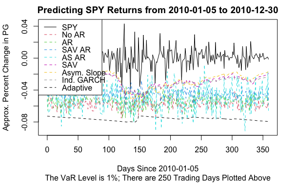

### 1% VaR Table - Multivariate Model

|  | No AR | AR | SAV AR | AS AR |
| --- | --- | --- | --- | --- |
| Losses | 0.146 | 0.136 | 0.114 | 0.128 |
| VaR Break Rate | 0.000 | 0.000 | 0.000 | 0.000 |

### 1% VaR - Optimal Parameters for Multivariate Model

|  | Optimal M | Optimal P |
| --- | --- | --- |
| No AR | 6 | NA |
| AR | 4 | 7 |
| SAV AR | 2 | 1 |
| AS AR | 3 | 7 |

### 5% VaR Graph

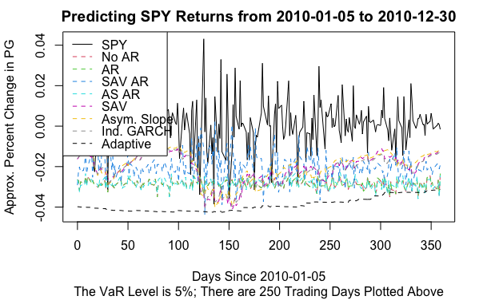

### 5% VaR Table - Multivariate Model

|  | No AR | AR | SAV AR | AS AR |
| --- | --- | --- | --- | --- |
| Losses | 0.394 | 0.394 | 0.436 | 0.397 |
| VaR Break Rate | 0.024 | 0.024 | 0.068 | 0.028 |

### 5% VaR Table - Univariate Model

|  | SAV | Asym. Slope | Ind. GARCH | Adaptive |
| --- | --- | --- | --- | --- |
| Losses | 0.336 | 0.336 | 0.343 | 0.492 |
| VaR Break Rate | 0.052 | 0.052 | 0.048 | 0.000 |

### 5% VaR - Optimal Parameters for Multivariate Model

|  | Optimal M | Optimal P |
| --- | --- | --- |
| No AR | 4 | NA |
| AR | 4 | 1 |
| SAV AR | 4 | 1 |
| AS AR | 4 | 1 |

### 10% VaR Graph

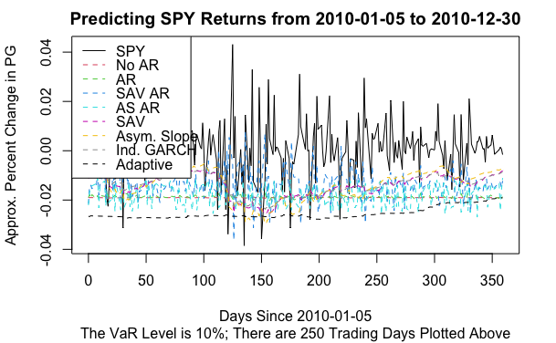

### 10% VaR Table - Multivariate Model

|  | No AR | AR | SAV AR | AS AR |
| --- | --- | --- | --- | --- |
| Losses | 0.595 | 0.594 | 0.664 | 0.596 |
| VaR Break Rate | 0.044 | 0.044 | 0.120 | 0.076 |

### 10% VaR Table - Univariate Model

|  | SAV | Asym. Slope | Ind. GARCH | Adaptive |
| --- | --- | --- | --- | --- |
| Losses | 0.547 | 0.549 | 0.546 | 0.690 |
| VaR Break Rate | 0.080 | 0.088 | 0.084 | 0.028 |

### 10% VaR - Optimal Parameters for Multivariate Model

|  | Optimal M | Optimal P |
| --- | --- | --- |
| No AR | 1 | NA |
| AR | 1 | 1 |
| SAV AR | 2 | 1 |
| AS AR | 4 | 2 |

The forecasts from the multivariate models are largely in line with those from the univariate CAViaR model. Generally, it seems like the univariate models do a better job tracking the response variable in the case of a large swing because of the moving average component. Also, while the multivariate models had a rate of VaR breaks that was too high for 2008, the rate of VaR breaks was generally too low for the multivariate models in 2010.

## 2014 Test Period - All ETFs

### 1% VaR Graph

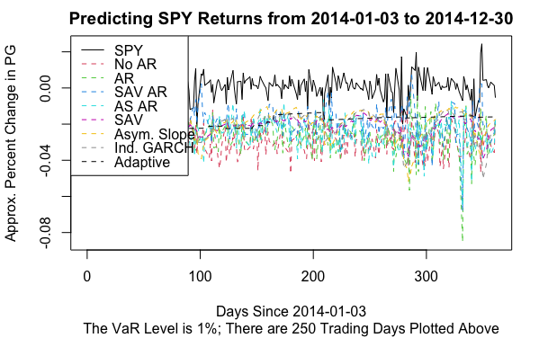

### 1% VaR Table - Multivariate Model

|  | No AR | AR | SAV AR | AS AR |
| --- | --- | --- | --- | --- |
| Losses | 0.087 | 0.073 | 0.107 | 0.079 |
| VaR Break Rate | 0.008 | 0.008 | 0.052 | 0.008 |

### 1% VaR Table - Univariate Model

|  | SAV | Asym. Slope | Ind. GARCH | Adaptive |
| --- | --- | --- | --- | --- |
| Losses | 0.061 | 0.057 | 0.063 | 0.061 |
| VaR Break Rate | 0.008 | 0.004 | 0.012 | 0.028 |

### 1% VaR - Optimal Parameters for Multivariate Model

|  | Optimal M | Optimal P |
| --- | --- | --- |
| No AR | 23 | NA |
| AR | 20 | 10 |
| SAV AR | 11 | 5 |
| AS AR | 13 | 9 |

### 5% VaR Graph

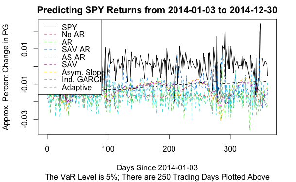

### 5% VaR Table - Multivariate Model

|  | No AR | AR | SAV AR | AS AR |
| --- | --- | --- | --- | --- |
| Losses | 0.241 | 0.256 | 0.320 | 0.246 |
| VaR Break Rate | 0.024 | 0.032 | 0.084 | 0.028 |

### 5% VaR Table - Univariate Model

|  | SAV | Asym. Slope | Ind. GARCH | Adaptive |
| --- | --- | --- | --- | --- |
| Losses | 0.226 | 0.218 | 0.225 | 0.240 |
| VaR Break Rate | 0.052 | 0.048 | 0.052 | 0.056 |

### 5% VaR - Optimal Parameters for Multivariate Model

|  | Optimal M | Optimal P |
| --- | --- | --- |
| No AR | 1 | NA |
| AR | 21 | 10 |
| SAV AR | 17 | 6 |
| AS AR | 22 | 4 |

### 10% VaR Graph

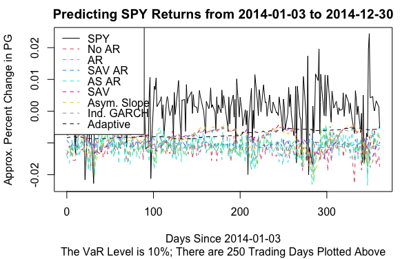

### 10% VaR Table - Multivariate Model

|  | No AR | AR | SAV AR | AS AR |
| --- | --- | --- | --- | --- |
| Losses | 0.371 | 0.359 | 0.370 | 0.361 |
| VaR Break Rate | 0.056 | 0.044 | 0.072 | 0.056 |

### 10% VaR Table - Univariate Model

|  | SAV | Asym. Slope | Ind. GARCH | Adaptive |
| --- | --- | --- | --- | --- |
| Losses | 0.367 | 0.359 | 0.364 | 0.368 |
| VaR Break Rate | 0.116 | 0.104 | 0.112 | 0.132 |

### 10% VaR - Optimal Parameters for Multivariate Model

|  | Optimal M | Optimal P |
| --- | --- | --- |
| No AR | 6 | NA |
| AR | 1 | 9 |
| SAV AR | 2 | 1 |
| AS AR | 1 | 8 |

## 2016 Test Period - All ETFs

### 1% VaR Graph

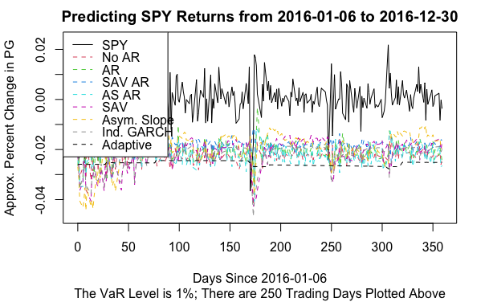

### 1% VaR Table - Multivariate Model

|  | No AR | AR | SAV AR | AS AR |
| --- | --- | --- | --- | --- |
| Losses | 0.091 | 0.097 | 0.092 | 0.083 |
| VaR Break Rate | 0.020 | 0.020 | 0.028 | 0.016 |

### 1% VaR Table - Univariate Model

|  | SAV | Asym. Slope | Ind. GARCH | Adaptive |
| --- | --- | --- | --- | --- |
| Losses | 0.078 | 0.082 | 0.078 | 0.077 |
| VaR Break Rate | 0.012 | 0.020 | 0.012 | 0.004 |

### 1% VaR - Optimal Parameters for Multivariate Model

|  | Optimal M | Optimal P |
| --- | --- | --- |
| No AR | 2 | NA |
| AR | 1 | 7 |
| SAV AR | 3 | 1 |
| AS AR | 2 | 2 |

### 5% VaR Graph

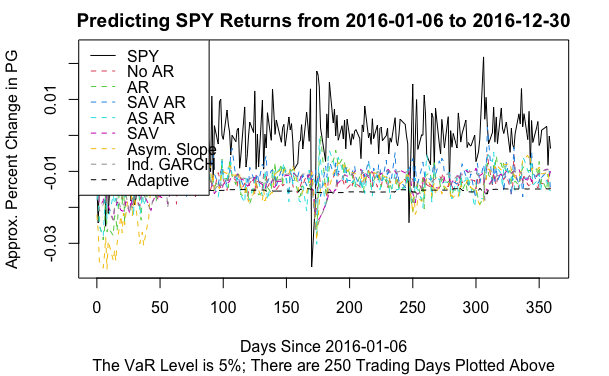

### 5% VaR Table - Multivariate Model

|  | No AR | AR | SAV AR | AS AR |
| --- | --- | --- | --- | --- |
| Losses | 0.26 | 0.265 | 0.283 | 0.272 |
| VaR Break Rate | 0.06 | 0.048 | 0.092 | 0.056 |

### 5% VaR Table - Univariate Model

|  | SAV | Asym. Slope | Ind. GARCH | Adaptive |
| --- | --- | --- | --- | --- |
| Losses | 0.238 | 0.238 | 0.234 | 0.264 |
| VaR Break Rate | 0.032 | 0.040 | 0.028 | 0.032 |

### 5% VaR - Optimal Parameters for Multivariate Model

|  | Optimal M | Optimal P |
| --- | --- | --- |
| No AR | 3 | NA |
| AR | 2 | 10 |
| SAV AR | 7 | 1 |
| AS AR | 2 | 7 |

### 10% VaR Graph

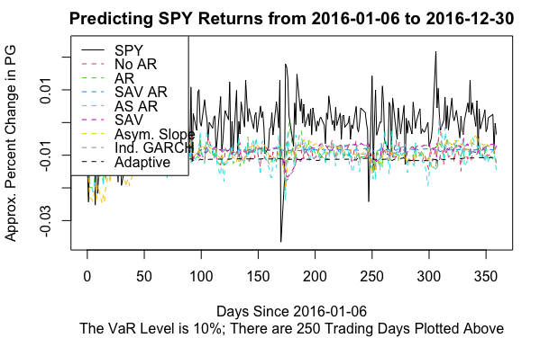

### 10% VaR Table - Multivariate Model

|  | No AR | AR | SAV AR | AS AR |
| --- | --- | --- | --- | --- |
| Losses | 0.425 | 0.397 | 0.401 | 0.441 |
| VaR Break Rate | 0.096 | 0.096 | 0.112 | 0.100 |

### 10% VaR Table - Univariate Model

|  | SAV | Asym. Slope | Ind. GARCH | Adaptive |
| --- | --- | --- | --- | --- |
| Losses | 0.370 | 0.373 | 0.368 | 0.414 |
| VaR Break Rate | 0.088 | 0.092 | 0.096 | 0.072 |

### 10% VaR - Optimal Parameters for Multivariate Model

|  | Optimal M | Optimal P |
| --- | --- | --- |
| No AR | 5 | NA |
| AR | 1 | 8 |
| SAV AR | 1 | 1 |
| AS AR | 5 | 6 |

As with 2010 and 2014, the results between model classes are similar. The multivariate models perform quite well with VaR breaks at the 5% and 10% level, and all the results (from both model classes) seem to be very closely clustered together.

# Conclusions and Future Work

The problem of how to predict a low quantile of a stock’s log return when the training sample is substantially different from the test scenario is an enormously difficult problem. Almost axiomatically, the distribution is nonstationary over time. How is it possible to predict the return of an index like the S&P500 during a period of market turmoil such as the Great Recession? While the univariate CAViaR model performs comparatively well during times of stress, it performs about the same as the multivariate CAViaR model during more benign economic periods.

This conclusion drawn from the above results might support the notion of combining the two models in some sort of a mixture model - aiming to use the basket of ETFs during good times, and use the CAViaR ARMA specification during bad times. The approach of using ETFs allows a prediction based on forward-looking expectations of fundamental factors. Indeed, ETFs are just baskets of individual stocks or bonds, and those securities are (in theory) based on rational expectations about future resources, market conditions, etc - the microfoundations of what drives our economy. The ARMA specification, while practically and statistically sound, is contradicted by economic theory and practice - the weak form of the efficient market hypothesis states that it is impossible to forecast future values of asset prices using past values. But perhaps this view is incomplete.

Any model that attempts to capture relationships in the real world will only work until an omitted variable is found. The elegance of the multivariate CAViaR model is that it provides insight into why a prediction is wrong; the change in the angle between resultant vectors is a sensible measurement of economic changepoints. However, errors in the real world are costly, and it is wishful thinking to say that explaining why the error occurred is sufficient.

As such, for future work it is worth exploring the notion of weighting an ARMA-approach more heavily when predictions using fundamentals were too high. Then, not only would this after-the-fact recognition be achieved, but also a hierarchical model that captures fundamental relationships in the economy and potentially changes our understanding of asset prices in general - a synthesis between Keynes’ animal spirits during a time of severe crisis; where a model cannot explain shifts, and a more rational world that explains other periods. In addition to significant predictive power because of the switching between the two worlds, there is also an elegant explanation; a way to explain changes in the usefulness of the underpinnings in the economy. Because of the flexibility of the model, it is entirely possible that a whole gamut of variables could be tossed in and backtested to determine when “changepoints” occurred.

Additional future work involves developing theoretical guarantees on the parameters in the multivariate CAViaR model. One advantage of both the diffusion index model and the CAViaR model is that both have theorems about asymptotic normality and consistency.

## Future Work - Changepoint Detection Algorithm

One advantage of the diffusion index model is the ability to detect changepoints in the underlying factors, which can serve as a proxy for economic changes. Below is a method that can be explored in future work:

1. Using a set of ETFs, perform PCA at $t$ many points for $m$ many factors - $f_{j,t}$
2. At each time point, add the vectors together to get a resultant: $\sum_{j=1}^m f_{j,t} = r_t$
3. Calculate the resultants at each time point $t$, giving $r_1, r_2, ..., r_T$.
4. Starting with a reference point $t_0$ with associated $r_{t0}$ resultant, measure the angle between resultants calculated at different time steps $r_{tk}$

$$\theta = \arccos \left(\frac{r_{t0} \cdot r_{tk}}{||r_{t0}|| ||r_{tk}||} \right)$$

The angle $\theta$ could be plotted over time, and changepoints could be detected using Monte Carlo simulation. The reason for using Monte Carlo simulation is that Principal Component Analysis transformations are non-linear, and so calculating an analytical density from the transformed data is intractable. Moreover, the data fed into the PCA transformation is non-normal, which further supports the notion of using Monte Carlo simulation to establish reasonable estimates of uncertainty for detected changepoints.

[output not shown]

# Acknowledgements

Early in my academic career, I grew to respect the University of Chicago as a truly special institution because of its unparalleled reputation in the field of Financial Econometrics and Statistics. I knew that when I received an offer to study as a master’s student that I could not turn it down. Despite all of the late nights working in the Regenstein library, in the John Crerar library, or in Jones, I can truly say that it has been the time of my life earning a master’s degree in Statistics at UChicago. Earning an M.S. degree is not the conclusion of my academic journey; I will be pursuing a Ph.D. in Statistics at the University of Wisconsin-Madison beginning in the fall of 2020. While I will be leaving Chicago this summer, I hope to maintain many of the connections that I have formed as a student. I have learned during this present crisis that an academic community doesn’t require proximity, and that is good news. I have also learned during my time here that the community at the University of Chicago is bound together by tireless, talented individuals who believe that above all else, often at great personal cost, that they have a commitment to find and share the truth with the world around them. And so let human life be enriched, as our motto goes.

As with many important steps in milestones in life, I must recognize that I did not reach them alone. I would like to thank my parents for their unwavering support and invaluable proofreading help. I would like to thank all of my family - my sister, my cousins, my aunts, my uncles, and my grandparents - for their commitments to me over the past 27 years. I would like to thank all of my friends - from Houston, from Rice University, from Dallas, from UChicago, and elsewhere for their support and check-ins through this process. I would like to thank my beautiful and brilliant girlfriend who has put up with close to two years of FaceTime calls and infrequent visits.

I must also thank Dr. Wei Biao Wu for his invaluable advising and mentorship. I would also like to thank Dr. Mei Wang for her guidance along this process as the M.S. advisor. In addition, Dr. Matthew Stephens, Dr. Ruey Tsay, and Dr. Lars Peter Hansen all deserve recognition for their suggestions to make this research possible. From Rice, I would like to thank Dr. James Brown for sharing his passion for economics, Dr. Illya Hicks for hiring me for my first research job, and Dr. Russell Green for giving me my first taste of economics research. None of this would be possible without you.

# Literature Cited

Amadeo, Kimberly. 2020. “How Bonds Affect the Stock Market.” *The Balance*. https://www.thebalance.com/how-bonds-affect-the-stock-market-3305603.

Becker, Gary. 2008. “We’re Not Headed for a Depression.” https://www.wsj.com/articles/SB122333679431409639.

Engle, Robert F, and Simone Manganelli. 2004. “CAViaR.” *Journal of Business & Economic Statistics* 22 (4). Taylor & Francis: 367–81. https://doi.org/10.1198/073500104000000370.

Fama, Eugene F. 1965. “The Behavior of Stock-Market Prices.” *The Journal of Business* 38 (1). University of Chicago Press: 34–105. http://www.jstor.org/stable/2350752.

Gant, Akhilesh. 2019. “Adjusted Closing Price Definition.” https://www.investopedia.com/terms/a/adjusted{\_}closing{\_}price.asp.

Holton, Glyn A. 2014. “History of VaR - Value-at-Risk: Theory and Practice.” https://www.value-at-risk.net/history-of-value-at-risk/.

Investopedia. 2019. “What is RiskMetrics in Value at Risk ( VaR )?” https://www.investopedia.com/ask/answers/041615/what-riskmetrics-value-risk-var.asp.

Keynes, John Maynard. 1923. *A tract on monetary reform,* London: Macmillan; Co., Limited.

Longerstaey, Jacques, and Martin Spencer. 1996. “RiskMetrics - Technical Document.” New York: J.P. Morgan/Reuters. http://www.jpmorgan.com/RiskManagement/RiskMetrics/RiskMetrics.html.

NA. 2017. “iShares Institutional Guide to Bond ETFs.” https://www.complianceweek.com/download?ac=5780.

———. 2020. “Sector ETFs | Seeking Alpha.” https://seekingalpha.com/etfs-and-funds/etf-tables/sectors.

Pechter, Kerry. 2020. “You Need to Understand the ‘Equity Risk Premium’.” https://www.forbes.com/sites/kerrypechter/2020/04/04/erp-zirp-and-when-to-get-back-into-the-market/{\#}36566af6e4d1.

PK. 2019. “S&P 500 Return Calculator, with Dividend Reinvestment.” https://dqydj.com/sp-500-return-calculator/.

Portnoy, Stephen. 1991. “Asymptotic behavior of regression quantiles in non-stationary, dependent cases.” *Journal of Multivariate Analysis* 38 (1): 100–113. https://doi.org/https://doi.org/10.1016/0047-259X(91)90034-Y.

Richardson, Matthew P., Jacob (Kobi) Boudoukh, and Robert F Whitelaw. 2005. “The Best of Both Worlds: A Hybrid Approach to Calculating Value at Risk.” *SSRN Electronic Journal*. https://doi.org/10.2139/ssrn.51420.

Stock, James H, and Mark W Watson. 2002a. “Macroeconomic Forecasting Using Diffusion Indexes.” *Journal of Business & Economic Statistics* 20 (2). Taylor & Francis: 147–62. https://doi.org/10.1198/073500102317351921.

———. 2002b. “Forecasting Using Principal Components from a Large Number of Predictors.” *Journal of the American Statistical Association* 97 (460). [American Statistical Association, Taylor & Francis, Ltd.]: 1167–79. http://www.jstor.org/stable/3085839.

Tsay, Ruey. 2014. *Multivariate Time Series Analysis*. John Wiley & Sons, Inc.